# Class5: Data Visualization with GGPLOT

# Plot of gene expression data

First read the data from online.

```r
url <- "https://bioboot.github.io/bimm143_S20/class-material/up_down_expression.txt"
genes <- read.delim(url)
head(genes)
```

```
##         Gene Condition1 Condition2      State
## 1      A4GNT -3.6808610 -3.4401355 unchanging
## 2       AAAS  4.5479580  4.3864126 unchanging
## 3      AASDH  3.7190695  3.4787276 unchanging
## 4       AATF  5.0784720  5.0151916 unchanging
## 5       AATK  0.4711421  0.5598642 unchanging
## 6 AB015752.4 -3.6808610 -3.5921390 unchanging
```

> Q. How many genes are in this dataset?

```r
nrow(genes)
```

```
## [1] 5196
```

What are the colnames?

```r
colnames(genes)
```

```
## [1] "Gene"       "Condition1" "Condition2" "State"
```

A first version plot of this data Condition1 vs Condition2

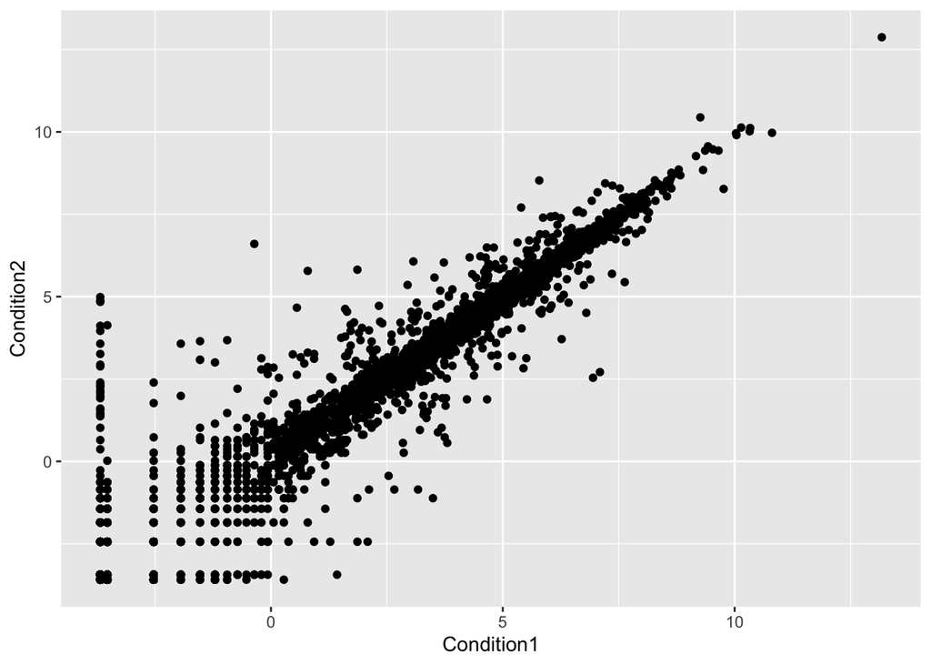

```r
ggplot(genes) +
  aes(x=Condition1, y=Condition2) +
  geom_point()
```

Let’s add some color. To do this we can add another aes() mapping of color to the ‘State’ column in our data.

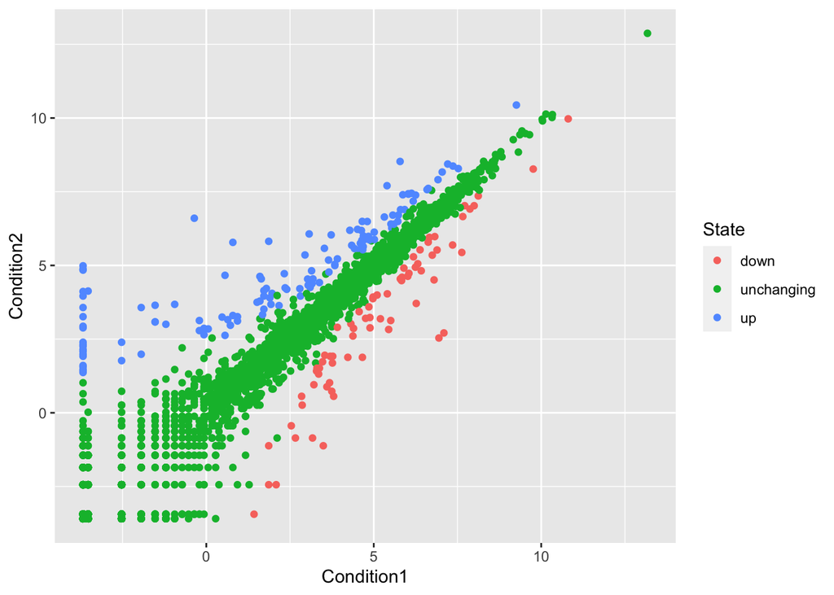

```r
ggplot(genes) +
  aes(x=Condition1, y=Condition2, col=State) +
  geom_point()
```

> Q. How many genes are up regulated and down regulated.

```r
head(genes)
```

```
##         Gene Condition1 Condition2      State
## 1      A4GNT -3.6808610 -3.4401355 unchanging
## 2       AAAS  4.5479580  4.3864126 unchanging
## 3      AASDH  3.7190695  3.4787276 unchanging
## 4       AATF  5.0784720  5.0151916 unchanging
## 5       AATK  0.4711421  0.5598642 unchanging
## 6 AB015752.4 -3.6808610 -3.5921390 unchanging
```

To get at just the State column

```r
table (genes$State)
```

```
##
##       down unchanging         up
##         72       4997        127
```

```r
p <- ggplot(genes) +
    aes(x=Condition1, y=Condition2, col=State) +
    geom_point()
```

We can add more layers

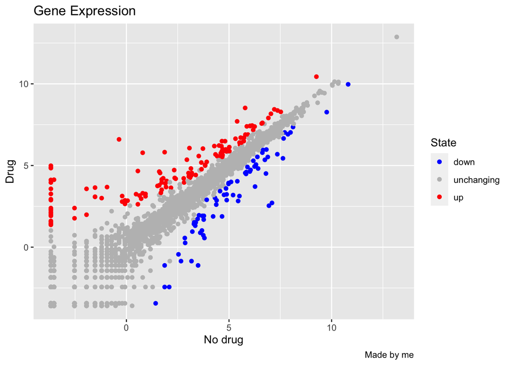

```r
p +scale_color_manual(values = (c ("blue", "gray", "red"))) +
  labs(title="Gene Expression",
   x= "No drug", y="Drug",
   caption= "Made by me")
```

Applying to geom_point applies it to the entire plot, aes is specific to the data set

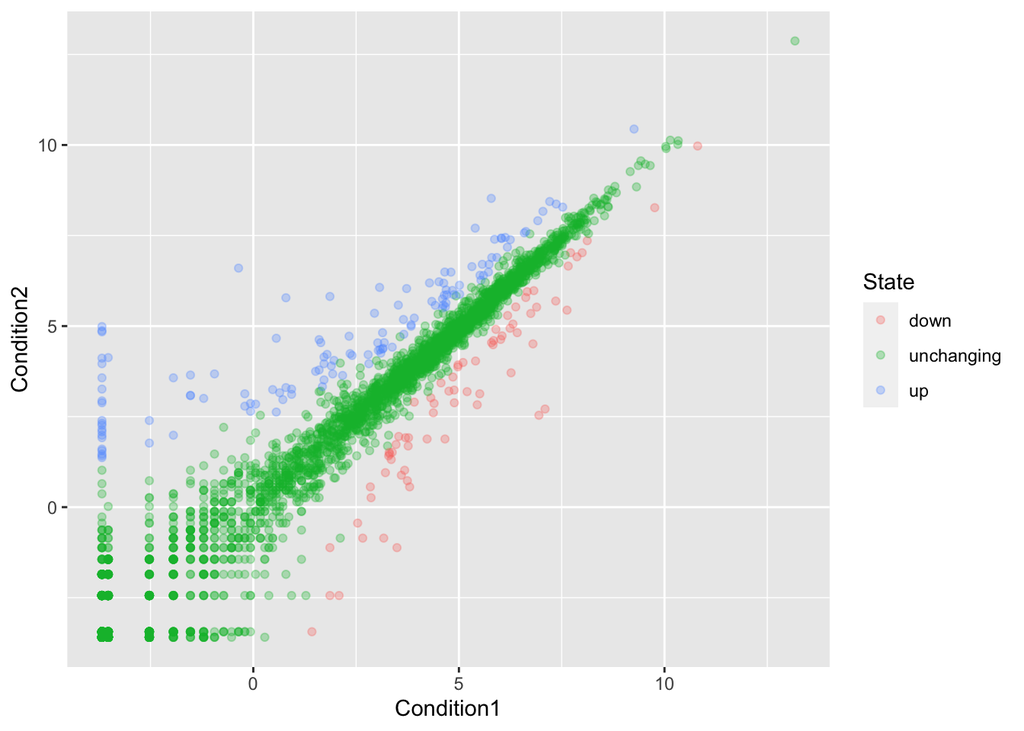

```r
 ggplot(genes) +
    aes(x=Condition1, y=Condition2, col=State) +
    geom_point(alpha=0.3)
```

p